# Complaints Summary

Roman Rivera

29 May, 2018

# Introduction

```r
oc <- read_csv('input/officer-filed-complaints__2017-09.csv.gz')
cmpl <- read_csv('input/complaints-complaints_2000-2016_2016-11.csv.gz') %>%
  mutate(complaint_class = if_else(cr_id %in% oc$cr_id, 'Officer', 'Civilian'),
         beat = as.numeric(beat)) %>%
  unique()

rm(oc)

acc <- read_csv('input/complaints-accused_2000-2016_2016-11.csv.gz') %>%
        select(cr_id, UID, recommended_finding, final_finding, complaint_category)
vict <- read_csv('input/complaints-victims_2000-2016_2016-11.csv.gz')
cmplnt <- read_csv('input/complaints-complainants_2000-2016_2016-11.csv.gz')
wit <- read_csv('input/complaints-witnesses_2000-2016_2016-11.csv.gz')

prof <- read_csv("input/final-profiles.csv.gz") %>%
  select(c("UID", "race", "gender", "birth_year", "appointed_date", "resignation_date")) %>%
  mutate(gender = recode(gender, MALE = 'Male', FEMALE = 'Female', .default='Unknown'),
         race = recode(race, BLACK = 'Black', HISPANIC = 'Hispanic', WHITE = 'White', .default = 'Other'))
```

This document is a general summary of the complaint data received via Freedom of Information Act (FOIA) requests to the Chicago Police Department (CPD) and the Independent Police Review Authority (IPRA), which was received in November of 2016. This data set contains information on complaints filed against police officers by other police officers and civilian, the classifications and outcomes of those complaints, complainants, victims, police officers acting as witnesses, and investigators. This is summary is meant as a brief overview of the complaints data, including trends, data quality issues, and historical context.

The complaints in this data correspond to incidents occuring between January 1, 2000 and June 17, 2016. There are a total of 109,339 complaint registry (CR) numbers in this data. A single CR number will be referred to as a ‘complaint’; a single complaint may name zero, one, or multiple officers, and each CR x officer combination will be referred to as an ‘accusation’, generally referring to accusations with identified officers; while in reality, a single accusation may be comprised of multiple ‘allegations’, meaning an officer in a complaint can be alleged to have committed multiple infractions (e.g. a single CR x officer combination having excessive force, uniform violation, and failure to provide services allegations) but in our data this level of granularity does not exist, so every accuation only has 1 allegation.

As noted, single complaint can correspond to multiple officers accused of misconduct. In total, there are 67,446 unique CR numbers resulting in 125,581 accusations filed against 16,021 CPD officers. The data on the victims of these complaints is more sparse than that of the accused officers. Only 16,847 complaints have victim information, and 47,042 complaints have complainant information. 11,346 officers are listed as witnesses for 12,606 unique complaints.

# Background

Complaints against CPD officers are routed through several investigative bodies. Most complaints are investigated internally. Minor allegations are investigated by an officer’s supervisors, while more serious complaints are handled by the CPD’s Bureau of Internal Affairs. Some [types](http://copadev.wpengine.com/investigations/jurisdiction/) of serious complaints, including use of force, racial slurs, and domestic violence are investigated by non-police investigators. Beginning in 1974, these cases were handled by the Office of Professional Standards ([OPS](https://www.hrw.org/legacy/reports98/police/uspo55.htm)), which employed civilian investigators but was still part of the CPD. After a series of police scandals in 2007, OPS was replaced with a new civilian agency, the Independent Police Review Authority ([IPRA](https://southsideweekly.com/the-origins-of-ipra/)), which operated outside of the CPD. In September 2017, in the wake of the killing of Laquan McDonald, IPRA was also deemed ineffective and replaced by another civilian oversight agency, the Civilian Office of Police Accountability ([COPA](http://www.chicagocopa.org/)).

# Complaint Filing Process

# Complaints

## Overview

```r
rm(vict, cmplnt, wit)

cmpl <- cmpl %>%
  mutate(district = if_else(! is.na(beat) & beat > 1,
                            beatToDistrict(as.character(beat)), NA_real_),
         incident_month = floor_date(ymd(incident_date), 'month'),
         incident_year = year(incident_date)) %>%
  select(cr_id, incident_date, incident_month, incident_year, incident_time,
         complaint_date, closed_date, district, complaint_class) %>%
  unique() %>%
 full_join(acc, by='cr_id')

stopifnot(nrow(keepDuplicates(cmpl)) == 0)

cym_tbl <- cmpl %>%
  select(incident_month, UID, cr_id) %>%
  filter(!is.na(UID)) %>%
  unique() %>%
  filter(incident_month < max(incident_month)) %>%
  select(incident_month) %>%
  table()

cym_pi_tbl <- cym_tbl[names(cym_tbl) >= IPRA_Active]
cmpl_xts <- cmpl %>%
  filter(!is.na(UID)) %>%
  unique() %>%
  mutate(incident_month = as.Date(incident_month)) %>%
  group_by(incident_month) %>%
  summarize(Accusations = n(),
            Sustained = sum(as.numeric(final_finding=='SU'), na.rm = T)) %>%
  tk_xts(.)

cmpl.full <- cmpl
```

As the complexity of any analysis would be greatly increased if data before IPRA was fully functional would increase dramatically, due to the obscurity and lack of accountability which prompted the reforms that led to IPRA’s creation, the rest of the summary will focus on the the period January of 2008, to our last full month of data December of 2015. This period is shown in the gray shading. Over the entire period, the number of accusations that are sustained, also shown on the plot below, remains low in comparison with the shear number of accusations.

```r
dygraph(tk_xts(cmpl_xts), main = "Accusations Over Time") %>%
dyRangeSelector() %>%
dyLegend(width = 500) %>%
dyAnnotation(IPRA_Active, text = "IPRA", width = 50, height=30, attachAtBottom=T) %>%
dyShading(from = IPRA_Active, to = '2007-10-01', color='#EE4242') %>%
dyOptions(stackedGraph = TRUE) %>%
  dyShading(from = sample_start_ym, to = sample_end_ym)
```

[interactive chart not shown]

```r
rm(cym_pi_tbl, cym_tbl, cmpl_xts)
```

## Sample Complaints

```r
cmpl <- cmpl %>%
  filter(!is.na(UID),
         between(incident_month, sample_start_ym, sample_end_ym)) %>%
  unique()
```

The observations kept for the majority of this analysis occured between 2008 and 2015, while IPRA was fully active and there is sufficient time for accusations to be investigated and a final finding (sustained, no sustained, exonerated, etc.) to be determined, and had identified officers accused of misconduct. During the sample period, total of 49,690 accusations resulted from 25,951 complaints. Of these, 49,690 accusations and 25,951 complaints had accused officers, accusing 11,013 unique officers. The accusation count declined by 68.74 percent over this time period, from 835 accusations in the first month to 261 accusations in the last.

## Complaint Category

````r
# HOW DO WE WANT TO BREAK THESE DOWN?
#   <!-- ## Complaints by Region replace with map -->
# <!-- ```{r by_region, cache=TRUE, dependson="sample"} -->
# <!-- # replace with map -->
# <!-- Min.District <- 1 -->
# <!-- Max.District <- 30 -->
# <!-- # look at this??? -->
# <!-- cmplt <- cmpl %>% -->
# <!--   select(district, incident_month) %>% -->
# <!--   filter(between(as.numeric(district), Min.District, Max.District)) %>% -->
# <!--   mutate(region = as.factor(districtToRegion(district))) -->
# <!-- ``` -->
# <!-- Chicago is divided up into `r length(unique(subset(cmpl, between(as.numeric(district), Min.District, Max.District))$district))` geographic districts-- though, in the past decade, these district boundaries have changed slightly. `r pnum(nrow(subset(cmpl, between(as.numeric(district), Min.District, Max.District))))` complaints in the relevant data have viable district numbers. These districts can be broken into three regions of Chicago: North, Central, and South. -->
#
# <!-- ```{r by_region_plot, cache=TRUE, dependson="by_region", fig.height = 5, fig.width = 7} -->
# <!-- cmplt %>%  -->
# <!--   group_by(incident_month, region) %>%  -->
# <!--   summarize(Complaints=n()) %>% -->
# <!--   ggplot(., aes(x=incident_month, y = Complaints, color=region, group=region)) +  -->
# <!--   geom_point(position='jitter') + -->
# <!--   geom_smooth(method = 'loess', span=0.1, alpha=0.1) +  -->
# <!--   ggtitle("Complaints by Region") +  -->
# <!--   labs(x = "Incident Month", y = "Complaints", color='Region') + -->
# <!--   theme(legend.position = c(0.9, 0.9)) -->
# <!-- rm(cmplt) -->
# <!-- ``` -->

# ******
````

# Accused Officers

```r
active_officers <-prof %>%
  filter(appointed_date <= sample_end_ym &
         (is.na(resignation_date) |
          resignation_date >= sample_start_ym))
```

```r
cmpl.ot <- merge(cmpl, prof, by = 'UID', all.x =T) %>%
  mutate(region = as.factor(districtToRegion(district))) %>%
  filter(!is.na(UID)) %>%
  select(cr_id, UID, gender, race, birth_year, appointed_date,
         region, incident_month, closed_date, incident_date,
         incident_year, final_finding, recommended_finding, complaint_class) %>%
  mutate(age_at_complaint = incident_year - birth_year,
         tenure_at_complaint = incident_year - year(appointed_date),
         `Age at Incident` = cut(age_at_complaint,
                                 breaks = c(20,30, 40, 50, 90),
                                 include.lowest=TRUE),
         `Tenure at Incident` = cut(tenure_at_complaint,
                                    breaks = c(0,5, 10, 15, 20, 50),
                                    include.lowest=TRUE))
```

There were 11,013 officers which were named in 49,690 accusations during in the sample period (between January of 2008 and December of 2015. There were roughly 16,462 active officers during this period, meaning about 66.9% of active officers were accused of misconduct– though a few of these accused officers may not have actually been active during the time of their accusations. The composition of officers accused of misconduct is roughly representative of the racial composition of the police force as a whole, but the upper ranks of the CPD are underrepresented (as would be expected) and thus older, white male officers are underrepresented. Additionally, female officers are noticably underrepresented relative to male officers across all races.

```r
niceTableStacked(cmpl.ot, 'race', c('gender', 'Age at Incident', 'Tenure at Incident', 'region'), scroll=F, caption = 'Accusations by Accused Officer Race')
```

Accusations by Accused Officer Race

|  | Black | Hispanic | Other | White | All |
| --- | --- | --- | --- | --- | --- |
| **Gender** |  |  |  |  |  |
| Female | 23.21 | 12.93 | 7.36 | 12.89 | 15.18 |
| Male | 76.79 | 87.07 | 92.64 | 87.11 | 84.82 |
| **Age At Incident** |  |  |  |  |  |
| [20,30] | 7.11 | 16.43 | 18.41 | 15.72 | 13.91 |
| (30,40] | 32.95 | 48.54 | 46.52 | 44.62 | 42.75 |
| (40,50] | 40.55 | 27.52 | 28.85 | 27.98 | 30.89 |
| (50,90] | 19.39 | 7.51 | 6.22 | 11.68 | 12.46 |
| **Tenure At Incident** |  |  |  |  |  |
| [0,5] | 18.3 | 26.85 | 28.05 | 20.56 | 21.59 |
| (5,10] | 24.25 | 31.55 | 35.07 | 29.09 | 28.65 |
| (10,15] | 21.95 | 21.67 | 21.22 | 23.68 | 22.76 |
| (15,20] | 19.05 | 10.89 | 11.11 | 14.85 | 14.89 |
| (20,50] | 16.45 | 9.04 | 4.55 | 11.82 | 12.11 |
| **Region** |  |  |  |  |  |
| Central | 40.14 | 40.16 | 28.78 | 35.06 | 37.16 |
| North | 12.76 | 34.6 | 47.85 | 36.78 | 30.96 |
| South | 47.1 | 25.24 | 23.37 | 28.16 | 31.87 |
| Observations | 11790 | 10597 | 1494 | 25809 | 49690 |
| % of Total | 23.73 | 21.33 | 3.01 | 51.94 | 100 |

## Unique Officers

```r
cmpl.otu <- cmpl.ot %>%
  group_by(UID) %>%
  summarise(Accusations = n(),
            race=max(race),
            gender=max(gender),
            birth_year=max(birth_year),
            `Officer Filed` = sum(as.numeric(complaint_class=='Officer')),
            `Civilian Filed` = sum(as.numeric(complaint_class=='Civilian')),
            Sustained = sum(as.numeric(final_finding=='SU' & !is.na(final_finding))))

cmpl.otu <- cmpl.otu %>% mutate(`Total Accusations` = cut(Accusations,
                                                         breaks = c(1,2,4,6,8,10,12, 14,18,26,
                                                                    max(cmpl.otu$Accusations)),
                                                         include.lowest=TRUE))

cmpl_dist_table <- round(prop.table(table(cmpl.otu$Accusations)) * 100, 2)
cmpl_break <- 10
cmpl_break2 <- 26

otu <- cmpl.otu %>% mutate(Male=as.numeric(gender=='Male'),
                           Female=as.numeric(gender=='Female'),
                           age = 2015 - birth_year) %>%
  select(c("Male", "Female", "race", 'age', 'Accusations','Officer Filed', 'Civilian Filed', 'Sustained'))
otu1 <- otu %>% select(-race) %>% summarise_all(funs(round(mean(.), 2))) %>% t()
colnames(otu1) <- 'All'

otu2 <- otu %>%  group_by(race) %>% summarise_all(funs(round(mean(.), 2))) %>% t()
colnames(otu2) <- otu2[1,]
otu2 <- otu2[-1, ]
otu_table <- cbind(otu2, otu1)
otu_table <- rbind(otu_table,
                   rbind(addmargins(table(unique(cmpl.otu[, c("race", "UID")])$race)),
                         round(addmargins(100 * prop.table(table(unique(cmpl.otu[, c("race", "UID")])$race))), 2)))
rownames(otu_table)[c(nrow(otu_table)-1, nrow(otu_table))] <- c("N","%")
```

White officers comprise a majority of the officers accused of misconduct (51.48%), while blacks make up a slightly larger share (24.77%) than Hispanics (20.73%). Black officers are more likely to be female (31%) than other races, reflecting the relative make up of the CPD in general. In terms of age, black officers (48.83) are older than whites (45.67), and Hispanics (43.38) are the youngest. Given the age and gender differences between officers of different races, some differences in number of accusations is to be expected.

Officers accused of misconduct have, on average, 4.51 accusations each, with Hispanics (4.64) having slightly more than whites (4.55) and blacks (4.32). However, black officers have clealry less civilian accusations (3.72) and more officer accusations (0.60) than other races. This may be related to the difference in number of sustained accusations, with blacks at 0.36 sustained accusations on average, while white and Hispanic officers have on average 0.20 and 0.23 sustained accusations, respectively.

```r
kable(otu_table, 'html', caption = "Unique Accused Officers") %>%
  kable_styling(c("striped", "bordered")) %>%
  group_rows("Demographics", 1, 3) %>%
  group_rows("Accusations", 4, 7) %>%
  group_rows("", 8, 9,label_row_css = "background-color: #D7261E")
```

Unique Accused Officers

|  | Black | Hispanic | Other | White | All |
| --- | --- | --- | --- | --- | --- |
| **Demographics** |  |  |  |  |  |
| Male | 0.69 | 0.82 | 0.89 | 0.83 | 0.8 |
| Female | 0.31 | 0.18 | 0.11 | 0.17 | 0.2 |
| age | 48.83 | 43.38 | 43.38 | 45.67 | 45.91 |
| **Accusations** |  |  |  |  |  |
| Accusations | 4.32 | 4.64 | 4.50 | 4.55 | 4.51 |
| Officer Filed | 0.60 | 0.43 | 0.45 | 0.41 | 0.46 |
| Civilian Filed | 3.72 | 4.21 | 4.05 | 4.14 | 4.05 |
| Sustained | 0.36 | 0.23 | 0.25 | 0.20 | 0.24 |
| N | 2728 | 2283 | 332 | 5670 | 11013 |
| % | 24.77 | 20.73 | 3.01 | 51.48 | 100 |

```r
ao_table <- addmargins(pcnt_table(active_officers$gender,active_officers$race))
kable(ao_table, 'html', caption = "Active Officers") %>%
  kable_styling(c("striped", "bordered"))
```

Active Officers

|  | Black | Hispanic | Other | White | Sum |
| --- | --- | --- | --- | --- | --- |
| Female | 8.23 | 4.00 | 0.35 | 10.68 | 23.26 |
| Male | 15.68 | 15.51 | 2.43 | 43.12 | 76.74 |
| Sum | 23.91 | 19.51 | 2.78 | 53.80 | 100.00 |

## Distribution of Accusations

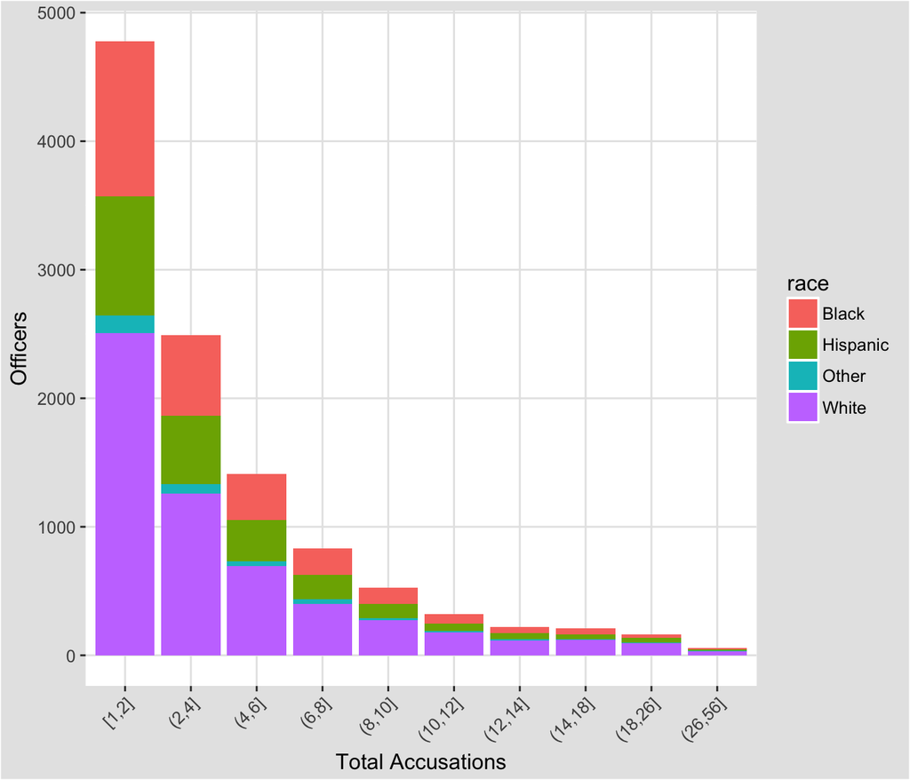

```r
cmpl.otu %>% ggplot(., aes(x = `Total Accusations`, fill=race)) + geom_bar() + labs(y='Officers') + rotate
```

```r
rm(otu, otu1, otu2, otu_table, cmpl_dist_table)
```

## Complaint Outcomes

```r
cmpl.f <- cmpl.ot %>%
filter(! is.na(final_finding), ! is.na(recommended_finding), ! is.na(closed_date)) %>%
filter(incident_year <= 2015) %>%
mutate(final_findingf = factor(final_finding),
complaint_class_nice = paste(complaint_class, " Filed"))
ff_table <- round(prop.table(table(cmpl.f$final_finding)) * 100,2)
```

> “Sustained” means the complaint was supported by sufficient evidence to justify disciplinary action. “Not sustained” means the evidence was insufficient to either prove or disprove the complaint. “Unfounded” means the facts revealed by the investigation did not support the complaint (e.g., the complained-of conduct did not occur). “Exonerated” means the complained-of conduct occurred, but the accused officer’s actions were proper under the circumstances.

### Outcomes for Civilian vs. Officer Complaints

A complaint (containing one or many accusations) can be filed by either a civilian (non-police officer) or a police officer against a member of the CPD. All accusation outcomes within a complaint do not have to be the same. From the plots below, it is clear that civilian complaints are much more likely to not have an affidavit signed compared to officer complaints. Similarly, given an affidavit is signed, officer complaints are fairly likely to end in a sustained (SU) finding.

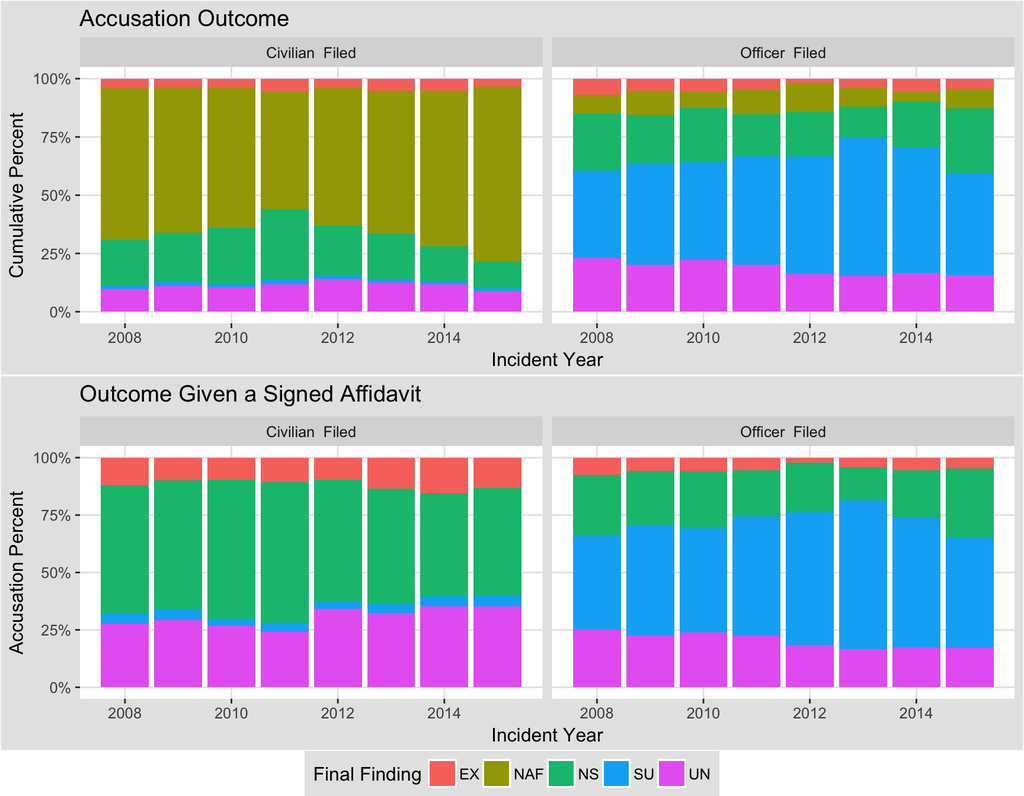

```r
cols <- gg_color_hue(length(unique(cmpl.f$final_findingf)))
names(cols) <- levels(unique(cmpl.f$final_findingf))
p1 <- cmpl.f %>%  ggplot(., aes(x=incident_year, fill=final_findingf)) + geom_bar(position='fill') + scale_fill_manual(values=cols) + facet_grid(~complaint_class_nice) + ggtitle("Accusation Outcome") + scale_y_continuous(labels=scales::percent) + labs(x = "Incident Year", y = "Cumulative Percent", fill='Final Finding')

p2 <- cmpl.f %>% filter(final_findingf!="NAF") %>% ggplot(., aes(x=incident_year, fill=final_findingf)) + geom_bar(position='fill') +  scale_fill_manual(values=cols) + facet_grid(~complaint_class_nice) + ggtitle("Outcome Given a Signed Affidavit") + scale_y_continuous(labels=scales::percent) + labs(x = "Incident Year", y = "Accusation Percent", fill='Final Finding')
grid_arrange_shared_legend(p1,p2, nrow=2, ncol=1)
```

```r
rm(p1,p2)
```

### Outcomes by Officer Demographics

```r
cc_table <- round(cbind(prop.table(table(subset(cmpl.f, complaint_class=='Civilian' & final_finding !='NAF')$final_finding,
subset(cmpl.f, complaint_class=='Civilian' &  final_finding!='NAF')$race),2),
prop.table(table(subset(cmpl.f,complaint_class=='Civilian' & final_finding!='NAF')$final_finding)))* 100,2)
colnames(cc_table)[5] <- c("All")

oc_table <- round(cbind(prop.table(table(subset(cmpl.f,complaint_class=='Officer' & final_finding!='NAF')$final_finding,
subset(cmpl.f,complaint_class=='Officer' &  final_finding!='NAF')$race),2),
prop.table(table(subset(cmpl.f, complaint_class=='Officer' & final_finding!='NAF')$final_finding))) * 100,2)
colnames(oc_table)[5] <- c("All")

occ_table <- cbind(cbind(cc_table,c("")) ,oc_table)
```

Given an affidavit was signed, officer complaints maintain an astoundingly larger sustained rate (50.76%) than civilian complaints (4.14%). However, in both officer and civilian filed complaints, black officers accused of misconduct are more likely to be sustained against. Accusations by officers against black officers are 57.7% sustained, compared the sustained percent of white and Hispanic officers (44.86 and 51.11, respectively). In civilian complaints, accusations against black officers are 5.98% sustained, compared the sustained percent of white and Hispanic officers (3.43 and 3.89, respectively).

```r
kable(occ_table, 'html', caption =  "Accusation Outcomes (Given Affidavit) by Accused Officer Race",
label_row_css = "background-color: #666; color: #fff;") %>%
kable_styling("striped", full_width = T, font_size = 14) %>%
add_header_above(c(" " = 1, "Civilian Filed" = 5, "   " = 1, "Officer Filed" = 5)) %>%
row_spec(3, background = 'yellow') %>%
column_spec(6, width = "1em")
```

Accusation Outcomes (Given Affidavit) by Accused Officer Race

|  | Civilian Filed Black | Civilian Filed Hispanic | Civilian Filed Other | Civilian Filed White | Civilian Filed All |  | Officer Filed Black | Officer Filed Hispanic | Officer Filed Other | Officer Filed White | Officer Filed All |
| --- | --- | --- | --- | --- | --- | --- | --- | --- | --- | --- | --- |
| EX | 11.03 | 10.78 | 9.52 | 11.52 | 11.19 |  | 3.62 | 5.97 | 9.35 | 6.23 | 5.38 |
| NS | 53.61 | 56.15 | 55.41 | 55.92 | 55.41 |  | 20.26 | 23.47 | 21.5 | 24.34 | 22.71 |
| SU | 5.98 | 3.89 | 3.9 | 3.43 | 4.14 |  | 57.7 | 51.11 | 57.94 | 44.86 | 50.76 |
| UN | 29.37 | 29.17 | 31.17 | 29.13 | 29.25 |  | 18.41 | 19.44 | 11.21 | 24.57 | 21.14 |

```r
rm(cc_table, oc_table, occ_table)
cmpl.pf <- cmpl.f %>%
  select(incident_date, final_finding, UID, race,cr_id) %>%
  group_by(UID) %>%
  arrange(UID, incident_date) %>%
  mutate(cmpl_total = n(),
         cmpl_num = 1,
         cmpl_num = cumsum(cmpl_num),
         SU = if_else(final_finding=='SU', 1, 0)) %>%
  ungroup()

p1 <- cmpl.pf %>%
  group_by(cmpl_num, race) %>%
  summarise(SUP = sum(SU)/n()) %>%
  ggplot(., aes(x = cmpl_num, y=SUP, group=race, color = race)) +
  geom_point() +
  geom_smooth(span=0.5, alpha=0.1, method='loess') +
  scale_y_continuous(labels=scales::percent)

p2 <- cmpl.pf %>%
  filter(cmpl_total < 12) %>%
  group_by(cmpl_num, race) %>%
  summarise(SUP = sum(SU)/n()) %>%
  ggplot(., aes(x = cmpl_num, y=SUP, group=race, color = race)) +
  geom_point() +
  geom_smooth(span=0.5, alpha=0.1, method='loess') +
  scale_y_continuous(labels=scales::percent)


rm(cmpl.pf, p1, p2, cmpl.otu)
```

### Outcomes over time

```r
cmpl.fy <- cmpl.f %>%
  group_by(incident_year,final_finding) %>%
  tally  %>%
  group_by(incident_year) %>%
  mutate(pct=round(100*n/sum(n),2))

cmpl.fym <- cmpl.f %>%
  group_by(incident_month,final_finding) %>%
  tally  %>%
  group_by(incident_month) %>%
  mutate(pct=round(100*n/sum(n),2)) %>% ungroup()

cfym_total <- cmpl.fym %>%
  select(incident_month, n, final_finding) %>%
  spread(final_finding, n) %>%
  tk_xts(.)

cfym_pct <- cmpl.fym %>%
  select(incident_month, pct, final_finding) %>%
  spread(final_finding, pct) %>%
  tk_xts(.)
```

```r
dateWindow <- c(sample_start_ym, sample_end_ym)

dygraph(cfym_total, main = "Count", group = "overtime") %>%
  dyLegend(width = 500) %>%
  dyRangeSelector(dateWindow = dateWindow)
```

[interactive chart not shown]

```r
dygraph(cfym_pct, main = "Percent", group = "overtime") %>%
  dyAxis("y", valueRange = c(0, 100)) %>%
  dyLegend(width = 500) %>%
  dyRangeSelector(dateWindow = dateWindow)
```

[interactive chart not shown]

```r
rm(ff_table, cfym_pct, cfym_total, cmpl.fy, cmpl.fym)
```

# Complainants and Victims

```r
cmplnt <- read_csv('input/complaints-complainants_2000-2016_2016-11.csv.gz')
vict <- read_csv('input/complaints-victims_2000-2016_2016-11.csv.gz')

cmpl_cv <- cmpl.full %>%
  select(cr_id, incident_month) %>%
  mutate(`Identified Complainant` = as.numeric(cr_id %in% cmplnt$cr_id),
         `Identified Victim` = as.numeric(cr_id %in% vict$cr_id),
         `Total Accusations` = 1,
         incident_month = ymd(incident_month)) %>%
  select(-cr_id) %>%
  group_by(incident_month) %>%
  summarise_all(funs(sum))
cmpl_cv_xts <- tk_xts(cmpl_cv)

cmpl_cv <- cmpl_cv %>%
  mutate(pct_cmplnt = `Identified Complainant`/`Total Accusations`,
         pct_vict = `Identified Victim`/`Total Accusations`)
```

```r
dateWindow <- c(min(cmpl_cv$incident_month), max(cmpl_cv$incident_month))

dygraph(cmpl_cv_xts, main = "All Accusations") %>%
  dyLegend(width = 600) %>%
  dyRangeSelector(dateWindow = dateWindow) %>%
  dyOptions(fillGraph = TRUE)
```

[interactive chart not shown]

```r
rm(cmpl_cv_xts, cmpl_cv)

cmplnt <- cmplnt %>%
  mutate(complainant = 1) %>%
  right_join(unique(cmpl[, c("cr_id","incident_year", "complaint_class")]), by='cr_id') %>%
  mutate(complainant = 1 - as.numeric(is.na(complainant)),
         complaint_class = paste0(complaint_class, " Filed"))

vict <- vict %>%
  mutate(victim = 1) %>%
  right_join(unique(cmpl[, c("cr_id","incident_year", "complaint_class")]), by='cr_id') %>%
  mutate(victim = 1 - as.numeric(is.na(victim)),
         complaint_class = paste0(complaint_class, " Filed"))
```

## Complainants and Victims in Sample

Focusing on the sample of complaints, it is clear that victim information is inconsistent for both civilian and officer filed complaints, but complainant information is almost fully known for officer filed complaints. Civilian filed complaints also have relatively consistent complainant information, but there is a considerable drop off in 2015.

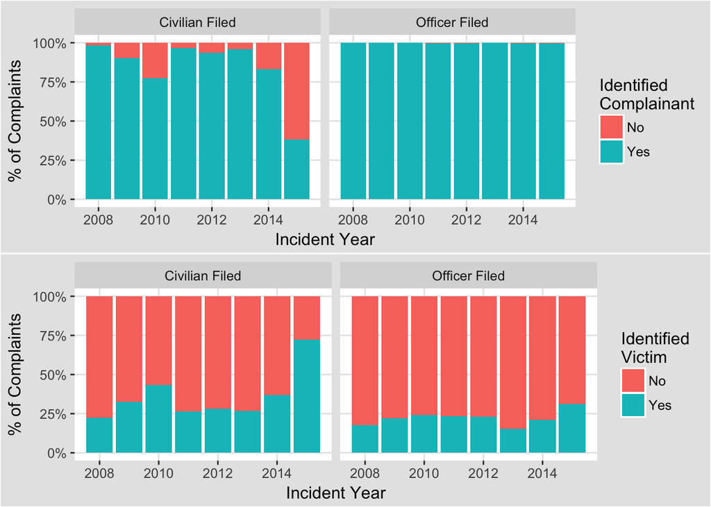

```r
p1 <- cmplnt %>%
  select(cr_id, complainant, complaint_class, incident_year) %>%
  unique() %>%
  mutate(`Identified \nComplainant` = if_else(complainant==1, 'Yes', 'No')) %>%
  ggplot(., aes(x = incident_year, fill=`Identified \nComplainant`)) +
  geom_bar(position='fill') +
  facet_grid(.~complaint_class) +
  scale_y_continuous(labels=scales::percent) +
  labs(x='Incident Year', y='% of Complaints')

p2 <- vict %>%
  select(cr_id, victim, complaint_class, incident_year) %>%
  unique() %>%
  mutate(`Identified \nVictim` = if_else(victim==1, 'Yes', 'No')) %>%
  ggplot(., aes(x = incident_year, fill=`Identified \nVictim`)) +
  geom_bar(position='fill') +
  facet_grid(.~complaint_class) +
  scale_y_continuous(labels=scales::percent) +
  labs(x='Incident Year', y='% of Complaints')

grid.arrange(p1, p2, ncol=1, nrow=2)
```

```r
rm(p1, p2)
```

## Demographics

```r
ctable <- cmplnt %>% filter(complainant==1) %>%
  select(c("gender", "race", 'age', 'complaint_class')) %>%
  mutate(race = recode(race,
                       'ASIAN/PACIFIC ISLANDER' = 'Other',
                       'NATIVE AMERICAN/ALASKAN NATIVE' = 'Other',
                       .default = str_to_title(race)),
         age_group = cut(age,
                         breaks = c(0,30, 45, 65, 110),
                         include.lowest=TRUE))

vtable <- vict %>% filter(victim==1) %>%
  select(c("gender", "race", 'age', 'complaint_class')) %>%
  mutate(race = recode(race,
                       'ASIAN/PACIFIC ISLANDER' = 'Other',
                       'NATIVE AMERICAN/ALASKAN NATIVE' = 'Other',
                       .default = str_to_title(race)),
         age_group = cut(age,
                         breaks = c(0,30, 45, 65, 110),
                         include.lowest=TRUE))
```

```r
niceTableStacked(list(ctable, vtable), 'race', c('gender', 'age_group', 'complaint_class'), scroll=F, caption = '',  headers=c("Complainants", "Victims"))
```

|  | Complainants Black | Complainants Hispanic | Complainants Other | Complainants White | Complainants All | Victims Black | Victims Hispanic | Victims Other | Victims White | Victims All |
| --- | --- | --- | --- | --- | --- | --- | --- | --- | --- | --- |
| **Gender** |  |  |  |  |  |  |  |  |  |  |
| FEMALE | 50.17 | 43.7 | 33.78 | 34.63 | 45.57 | 34.9 | 34.28 | 30 | 40.8 | 35.52 |
| MALE | 49.83 | 56.3 | 66.22 | 65.37 | 54.43 | 65.1 | 65.72 | 70 | 59.2 | 64.48 |
| **Age_group** |  |  |  |  |  |  |  |  |  |  |
| [0,30] | 16.27 | 18.64 | 14.05 | 6.79 | 14.36 | 47.62 | 51.35 | 27.42 | 29.72 | 45.87 |
| (30,45] | 42.69 | 43.18 | 42.7 | 28.24 | 39.45 | 31.42 | 29.71 | 45.16 | 37.33 | 31.98 |
| (45,65] | 36.67 | 36.08 | 38.92 | 59.64 | 41.86 | 18.02 | 16.92 | 24.19 | 28.47 | 19.16 |
| (65,110] | 4.38 | 2.09 | 4.32 | 5.33 | 4.33 | 2.94 | 2.02 | 3.23 | 4.48 | 2.99 |
| **Complaint_class** |  |  |  |  |  |  |  |  |  |  |
| Civilian Filed | 93.37 | 81.15 | 79.28 | 54.85 | 82.69 | 93.16 | 90.1 | 77.78 | 83.01 | 91.25 |
| Officer Filed | 6.63 | 18.85 | 20.72 | 45.15 | 17.31 | 6.84 | 9.9 | 22.22 | 16.99 | 8.75 |
| Observations | 14055 | 2636 | 222 | 5218 | 22131 | 6770 | 1444 | 90 | 1224 | 9528 |
| % of Total | 63.51 | 11.91 | 1 | 23.58 | 100 | 71.05 | 15.16 | 0.94 | 12.85 | 100 |

## Complainants and Accused Officers

Considering the more complete information of complainants, we will continue focusing on their information.

```r
rm(ctable, vtable, vict)
cmplnt <- cmplnt %>%
  mutate(race = recode(race,BLACK = 'Black', HISPANIC = 'Hispanic', WHITE = 'White', .default = 'Other')) %>%
  select(cr_id, complainant_gender=gender, complainant_race=race, complainant_age=age)

cmpl.c <- cmpl.ot %>%
  select(cr_id,UID, incident_date, incident_month, incident_year, complaint_class, final_finding, officer_race=race, officer_gender=gender) %>%
  inner_join(cmplnt, 'cr_id')

cao_table <- round(100 * addmargins(prop.table(table(cmpl.c$officer_race, cmpl.c$complainant_race), 1), 2), 2)
```

The table below, displaying complainant racial breakdown with respect to officer race, shows a not unexpected relationship. Black complainants make up a larger share of black officer accusations (77.55%), while Hispanic complainants maintain their largest share in Hispanic officer complaints (17.29%).

```r
kable(cao_table, 'html') %>%
  kable_styling(c("striped", "bordered")) %>%
  add_header_above(c(" "=1, "Complainant"=5)) %>%
  group_rows("Officer", 1, 4)
```

|  | Complainant Black | Complainant Hispanic | Complainant Other | Complainant White | Complainant Sum |
| --- | --- | --- | --- | --- | --- |
| **Officer** |  |  |  |  |  |
| Black | 77.55 | 4.98 | 0.78 | 16.69 | 100 |
| Hispanic | 62.56 | 17.29 | 0.76 | 19.40 | 100 |
| Other | 61.02 | 13.50 | 2.16 | 23.32 | 100 |
| White | 65.72 | 12.19 | 0.98 | 21.11 | 100 |

## Complainants and Outcomes

```r
cmpl.c$complaint_class_nice <- paste0(cmpl.c$complaint_class, " Filed")
cmpl.co <- subset(cmpl.c, complaint_class=='Officer' & ! is.na(final_finding))
cmpl.cc <- subset(cmpl.c, complaint_class=='Civilian' & ! is.na(final_finding))

tabon <- round(100 * addmargins(prop.table(table(cmpl.co$complainant_race, cmpl.co$final_finding), 1),2), 2)
taboa <- round(100 * addmargins(prop.table(table(subset(cmpl.co, final_finding !='NAF')$complainant_race,
                                                 subset(cmpl.co, final_finding !='NAF')$final_finding), 1),2), 2)

tabcn <- round(100 * addmargins(prop.table(table(cmpl.cc$complainant_race, cmpl.cc$final_finding), 1),2), 2)
tabca <- round(100 * addmargins(prop.table(table(subset(cmpl.cc, final_finding !='NAF')$complainant_race,
                                                 subset(cmpl.cc, final_finding !='NAF')$final_finding), 1),2), 2)
tab <- rbind(
  cbind(tabcn, c(" "), tabca),
  cbind(tabon, c(" "), taboa)
)
```

The sustained rates for all civilian accusations are miniscule compared to those of officer complaints. This section only includes the 46052 accusations with non-missing final findings. Focusing on accusations with affidavits, white civilian-complainant accusations are sustained at a rate of 9.66%, which is 3 times the rate of black civilian-complainant accusations (3.17%) and 2.3 times the rate of Hispanic. civilian-complainant accusations (4.22%). This is a considerable disparity. In officer filed accusations, there are still racial disparities, but to a lesser extent. Black complainant-officers have their accusations sustained at the lowest rate of 43.14%, followed by Hispanic officers (50.72%) and White officers (53.94%). Interestingly, Black officer complainants sign affidavits at a lower rate than other officers (11.56% compared to 8.88% and 7.66% for Hispanic and white officers, respectively).

```r
kable(tab, 'html') %>%
kable_styling(c("striped", "bordered")) %>%
add_header_above(c(" "=1,"All Accusations" = 6, " "=1, "Accusations with Affidavits"= 5)) %>%
add_header_above(c("","Final Finding by Complainant Race (%)" = 12)) %>%
group_rows("Civilian", 1, 4) %>%
group_rows("Officer", 5, 8) %>%
column_spec(7, width = "3em") %>%
column_spec(c(5,11), background="yellow", bold=T)
```

|  | Final Finding by Complainant Race (%) All Accusations EX | Final Finding by Complainant Race (%) All Accusations NAF | Final Finding by Complainant Race (%) All Accusations NS | Final Finding by Complainant Race (%) All Accusations SU | Final Finding by Complainant Race (%) All Accusations UN | Final Finding by Complainant Race (%) All Accusations Sum | Final Finding by Complainant Race (%) | Final Finding by Complainant Race (%) Accusations with Affidavits EX | Final Finding by Complainant Race (%) Accusations with Affidavits NS | Final Finding by Complainant Race (%) Accusations with Affidavits SU | Final Finding by Complainant Race (%) Accusations with Affidavits UN | Final Finding by Complainant Race (%) Accusations with Affidavits Sum |
| --- | --- | --- | --- | --- | --- | --- | --- | --- | --- | --- | --- | --- |
| **Civilian** |  |  |  |  |  |  |  |  |  |  |  |  |
| Black | 4.57 | 59.11 | 23.11 | 1.3 | 11.92 | 100 |  | 11.18 | 56.51 | 3.17 | 29.14 | 100 |
| Hispanic | 3.74 | 54.76 | 27.56 | 1.91 | 12.03 | 100 |  | 8.27 | 60.92 | 4.22 | 26.59 | 100 |
| Other | 3.42 | 66.1 | 14.38 | 3.42 | 12.67 | 100 |  | 10.1 | 42.42 | 10.1 | 37.37 | 100 |
| White | 5.42 | 61.77 | 18.56 | 3.69 | 10.55 | 100 |  | 14.19 | 48.55 | 9.66 | 27.6 | 100 |
| **Officer** |  |  |  |  |  |  |  |  |  |  |  |  |
| Black | 3.88 | 11.56 | 26.42 | 38.15 | 19.98 | 100 |  | 4.39 | 29.88 | 43.14 | 22.6 | 100 |
| Hispanic | 4.11 | 8.88 | 21.55 | 46.22 | 19.24 | 100 |  | 4.51 | 23.65 | 50.72 | 21.12 | 100 |
| Other | 6 | 4 | 18 | 60 | 12 | 100 |  | 6.25 | 18.75 | 62.5 | 12.5 | 100 |
| White | 4.96 | 7.66 | 19.69 | 49.81 | 17.89 | 100 |  | 5.37 | 21.32 | 53.94 | 19.37 | 100 |

# Officer Witnesses

```r
wit <- read_csv('input/complaints-witnesses_2000-2016_2016-11.csv.gz') %>%
  select(cr_id, UID) %>%
  filter(!is.na(UID)) %>%
  mutate(Witness = 1) %>%
  unique()

wit_xts <- unique(wit[, c("Witness", "cr_id")]) %>%
  full_join(cmpl.full[, c("cr_id", "incident_month")], by='cr_id') %>%
  select(cr_id, incident_month, Witness) %>%
  group_by(incident_month) %>%
  summarise(`All Complaints` = n(),
            `With Any Witness` = sum(as.numeric(!is.na(Witness)))) %>%
  tk_xts(.)
```

```r
dateWindow <- c(min(cmpl.full$incident_month), max(cmpl.full$incident_month))

dygraph(wit_xts, main = "Complaints") %>%
  dyLegend(width = 600) %>%
  dyRangeSelector(dateWindow = dateWindow) %>%
  dyOptions(fillGraph = TRUE)
```

[interactive chart not shown]

## Witness Demographics

```r
wit <- full_join(wit, prof, by='UID') %>%
  inner_join(cmpl[, c("cr_id", "complaint_class")])
wtu <- wit %>%
  mutate(Male=as.numeric(gender=='Male'),
         Female=as.numeric(gender=='Female'),
         Age = 2015 - birth_year,
         `In Complaints` = as.numeric(UID %in% acc$UID)) %>%
  filter(!is.na(race)) %>%
  select(c("Male", "Female", "race", 'Age', "In Complaints"))
wtu1 <- wtu %>% select(-race) %>% summarise_all(funs(mean(., na.rm=T))) %>% t()
colnames(wtu1) <- 'All'

wtu2 <- wtu %>%  group_by(race) %>% summarise_all(funs(mean(., na.rm=T))) %>% t()
colnames(wtu2) <- wtu2[1,]
wtu2 <- wtu2[-1, ]
wtu_table <- cbind(wtu2, wtu1)
wtu_table <- rbind(wtu_table,
                   rbind(addmargins(table(unique(wit[, c("race", "UID")])$race)),
                         addmargins(100 * prop.table(table(unique(wit[, c("race", "UID")])$race)))))
rownames(wtu_table)[c(nrow(wtu_table)-1,nrow(wtu_table))] <- c("N","%")

for (col in colnames(wtu_table)) {
  wtu_table[,col] <- round(as.numeric(wtu_table[,col]),2)
}
```

Witness officers are demographically similar to accused officers, in race, age, and gender. Interestingly, almost all witness officers (96%) are named in the full accused officer data.

```r
kable(wtu_table, 'html', caption = "Unique Witness Officers") %>%
  add_footnote(c(paste0(length(unique(wit[is.na(wit$race), 'UID'])), " officers dropped due to no race information.")), notation = "number") %>%
  kable_styling(c("striped", "bordered")) %>%
  group_rows("", nrow(wtu_table)-1,nrow(wtu_table),label_row_css = "background-color: #D7261E")
```

Unique Witness Officers

|  | Black | Hispanic | Other | White | All |
| --- | --- | --- | --- | --- | --- |
| Male | 0.7 | 0.8 | 0.87 | 0.82 | 0.79 |
| Female | 0.3 | 0.2 | 0.13 | 0.18 | 0.21 |
| Age | 47.41 | 42.36 | 43.01 | 44.5 | 44.74 |
| In Complaints | 0.97 | 0.98 | 0.98 | 0.95 | 0.96 |
| N | 1324 | 1100 | 155 | 2777 | 5356 |
| % | 24.72 | 20.54 | 2.89 | 51.85 | 100 |

<sup>1</sup> 1 officers dropped due to no race information.

# Investigators

```r
inv <- read_csv('input/complaints-investigators_2000-2016_2016-11.csv.gz') %>%
  select(cr_id, `complaints-investigators_2000-2016_2016-11_ID`, UID) %>%
  mutate(INV = 1,
         POI = as.numeric(!is.na(UID)),
         CI = as.numeric(is.na(UID))) %>%
  unique()

inv_xts <- unique(inv[, c("INV","CI", "POI", "cr_id")]) %>%
  full_join(cmpl.full[, c("cr_id", "incident_month")], by='cr_id') %>%
  select(cr_id, incident_month, POI, CI, INV) %>%
  group_by(incident_month) %>%
  summarise(`All Complaints` = n(),
            `Any Investigator` = sum(as.numeric(!is.na(INV))),
            `PO Investigator` = sum(POI, na.rm = T),
            `Citizen Investigator` = sum(CI, na.rm = T)) %>%
  tk_xts(.)
```

Investigators fall into two categories: police officer acting as investigators and civilian investigators from IPRA (post creation of IPRA). In total, there are 3,198, with about 93% of the known unique investigators being police officers, investigating 69.5% of complaints. Non-officer investigators comprise only 7% of investigators, but investigate 30.5% of complaints.

```r
dateWindow <- c(min(cmpl.full$incident_month), max(cmpl.full$incident_month))

dygraph(inv_xts, main = "Complaints") %>%
  dyLegend(width = 600) %>%
  dyRangeSelector(dateWindow = dateWindow) %>%
  dyOptions(fillGraph = TRUE)
```

[interactive chart not shown]

## Police Investigator Demographics

```r
pinv <- inner_join(inv, prof, by='UID') %>%
  inner_join(cmpl[, c("cr_id", "complaint_class", "final_finding", "incident_year")], by='cr_id')
pinvu <- pinv %>%
  mutate(Male=as.numeric(gender=='Male'),
         Female=as.numeric(gender=='Female'),
         `Age at Incident` = incident_year - birth_year,
         `In Complaints` = as.numeric(UID %in% acc$UID),
         Sustained = as.numeric(final_finding=='SU'),
         Allegations = 1) %>%
  filter(!is.na(race)) %>%
  group_by(UID, race, Male, Female, `In Complaints`) %>%
  summarize(Sustained = sum(Sustained, na.rm = T),
            Allegations = sum(Allegations),
            `Sustained Rate` = sum(Sustained, na.rm = T)/sum(Allegations),
            `Age at Incident` = mean(`Age at Incident`)) %>%
  ungroup() %>%
  select(-UID)
pinvu1 <- pinvu %>% select(-race) %>% summarise_all(funs(mean(., na.rm=T))) %>% t()
colnames(pinvu1) <- 'All'
pinvu2 <- pinvu %>%  group_by(race) %>% summarise_all(funs(mean(., na.rm=T))) %>% t()
colnames(pinvu2) <- pinvu2[1,]
pinvu2 <- pinvu2[-1, ]
pinvu_table <- cbind(pinvu2, pinvu1)
pinvu_table <- rbind(pinvu_table,
                   rbind(addmargins(table(unique(pinv[, c("race", "UID")])$race)),
                         addmargins(100 * prop.table(table(unique(pinv[, c("race", "UID")])$race)))))
rownames(pinvu_table)[c(nrow(pinvu_table)-1,nrow(pinvu_table))] <- c("N","%")

for (col in colnames(pinvu_table)) {
  pinvu_table[,col] <- round(as.numeric(pinvu_table[,col]),2)
}
```

```r
# Mean age at incident is computed as average of average for each officer
kable(pinvu_table, 'html', caption = "Unique Officer Investigators") %>%
  kable_styling(c("striped", "bordered")) %>%
  group_rows("", nrow(pinvu_table)-1,nrow(pinvu_table),label_row_css = "background-color: #D7261E")
```

Unique Officer Investigators

|  | Black | Hispanic | Other | White | All |
| --- | --- | --- | --- | --- | --- |
| Male | 0.71 | 0.82 | 0.93 | 0.84 | 0.82 |
| Female | 0.29 | 0.18 | 0.07 | 0.16 | 0.18 |
| In Complaints | 0.93 | 0.95 | 1 | 0.94 | 0.94 |
| Sustained | 1.99 | 0.88 | 0.07 | 1.08 | 1.18 |
| Allegations | 32.33 | 21.86 | 12.15 | 17.48 | 20.36 |
| Sustained Rate | 0.08 | 0.06 | 0 | 0.06 | 0.06 |
| Age at Incident | 49.2 | 46.73 | 43.41 | 47.72 | 47.75 |
| N | 284 | 256 | 27 | 1236 | 1803 |
| % | 15.75 | 14.2 | 1.5 | 68.55 | 100 |